# SVM_In_CNN

## Problem Statement:

### Pedicting effective treatments for diabetes in turn reducing the readmission into the hospital

```python
# This Python 3 environment comes with many helpful analytics libraries installed
# It is defined by the kaggle/python docker image: https://github.com/kaggle/docker-python
# For example, here's several helpful packages to load in

import numpy as np # linear algebra
import pandas as pd # data processing, CSV file I/O (e.g. pd.read_csv)
```

```python
data = pd.read_csv('diabetic_data.csv')
data.shape
```

```
(101766, 50)
```

# Data Preparation

```python
data.columns
```

```
Index(['encounter_id', 'patient_nbr', 'race', 'gender', 'age', 'weight',
       'admission_type_id', 'discharge_disposition_id', 'admission_source_id',
       'time_in_hospital', 'payer_code', 'medical_specialty',
       'num_lab_procedures', 'num_procedures', 'num_medications',
       'number_outpatient', 'number_emergency', 'number_inpatient', 'diag_1',
       'diag_2', 'diag_3', 'number_diagnoses', 'max_glu_serum', 'A1Cresult',
       'metformin', 'repaglinide', 'nateglinide', 'chlorpropamide',
       'glimepiride', 'acetohexamide', 'glipizide', 'glyburide', 'tolbutamide',
       'pioglitazone', 'rosiglitazone', 'acarbose', 'miglitol', 'troglitazone',
       'tolazamide', 'examide', 'citoglipton', 'insulin',
       'glyburide-metformin', 'glipizide-metformin',
       'glimepiride-pioglitazone', 'metformin-rosiglitazone',
       'metformin-pioglitazone', 'change', 'diabetesMed', 'readmitted'],
      dtype='object')
```

```python
data.info()
```

```
<class 'pandas.core.frame.DataFrame'>
RangeIndex: 101766 entries, 0 to 101765
Data columns (total 50 columns):
 #   Column                    Non-Null Count   Dtype
---  ------                    --------------   -----
 0   encounter_id              101766 non-null  int64
 1   patient_nbr               101766 non-null  int64
 2   race                      101766 non-null  object
 3   gender                    101766 non-null  object
 4   age                       101766 non-null  object
 5   weight                    101766 non-null  object
 6   admission_type_id         101766 non-null  int64
 7   discharge_disposition_id  101766 non-null  int64
 8   admission_source_id       101766 non-null  int64
 9   time_in_hospital          101766 non-null  int64
```

[output cut: 42 more lines]

```python
data.isnull().values.any()
```

```
False
```

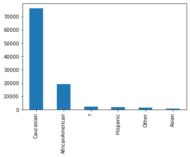

```python
data.race.value_counts().plot(kind = 'bar' )
```

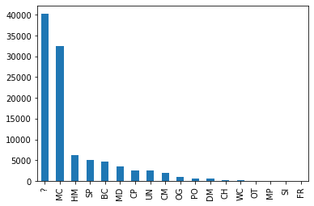

```python
data.payer_code.value_counts().plot(kind = 'bar' )
```

```python
data.medical_specialty.value_counts()
```

```
?                                49949
InternalMedicine                 14635
Emergency/Trauma                  7565
Family/GeneralPractice            7440
Cardiology                        5352
                                 ...
SportsMedicine                       1
Speech                               1
Perinatology                         1
Neurophysiology                      1
Pediatrics-InfectiousDiseases        1
Name: medical_specialty, Length: 73, dtype: int64
```

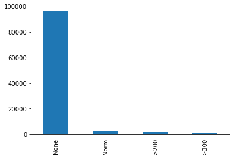

```python
data.max_glu_serum.value_counts().plot(kind = 'bar' )
```

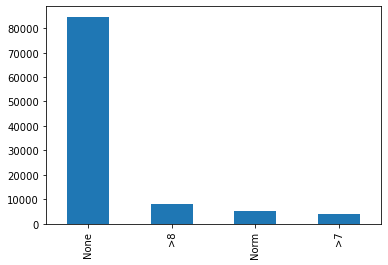

```python
data.A1Cresult.value_counts().plot(kind = 'bar' )
```

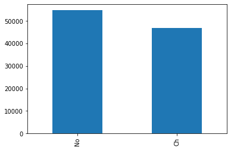

```python
data.change.value_counts().plot(kind = 'bar' )
```

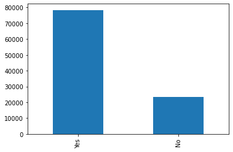

```python
data.diabetesMed.value_counts().plot(kind = 'bar' )
```

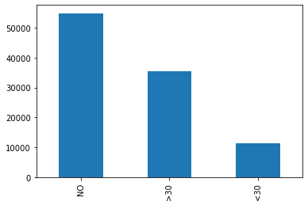

```python
data.readmitted.value_counts().plot(kind = 'bar' )
```

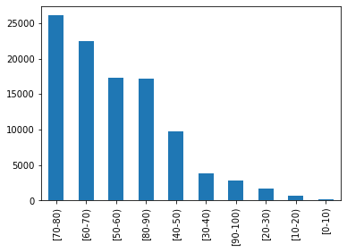

```python
data.age.value_counts().plot(kind = 'bar')
```

## Filtering patients with Diabetes

### diabetesMed = Yes

```python
data=data[data.diabetesMed=='Yes']
data.shape
```

```
(78363, 50)
```

## Filtering patients who didn't readmit

### readmission = NO

```python
data=data[data.readmitted=='NO']
data.shape
```

```
(40934, 50)
```

## Excluding patients who are Dead and are in hospise

```python
data=data[~data.discharge_disposition_id.isin([11,13,14,19,20])]
data.shape
```

```
(39355, 50)
```

# Handling Missing Values

```python
data = data.drop(['medical_specialty','payer_code','weight'],axis=1)
```

**We can observe that the "Race" Feature has some missing values**

**Missing value Imputation using MODE for Race Feature as most of the people in the Dataset are Caucasian**

##### 1. Replacing the ? with NaN's

```python
data['race']=data.race.replace('?',np.nan)
```

##### 2. Filling the NaN's with the mode

```python
data['race'].fillna(data['race'].mode()[0], inplace=True)
```

```python
data.race.isnull().sum()
```

```
0
```

```python
data.shape
```

```
(39355, 47)
```

```python
data.columns
```

```
Index(['encounter_id', 'patient_nbr', 'race', 'gender', 'age',
       'admission_type_id', 'discharge_disposition_id', 'admission_source_id',
       'time_in_hospital', 'num_lab_procedures', 'num_procedures',
       'num_medications', 'number_outpatient', 'number_emergency',
       'number_inpatient', 'diag_1', 'diag_2', 'diag_3', 'number_diagnoses',
       'max_glu_serum', 'A1Cresult', 'metformin', 'repaglinide', 'nateglinide',
       'chlorpropamide', 'glimepiride', 'acetohexamide', 'glipizide',
       'glyburide', 'tolbutamide', 'pioglitazone', 'rosiglitazone', 'acarbose',
       'miglitol', 'troglitazone', 'tolazamide', 'examide', 'citoglipton',
       'insulin', 'glyburide-metformin', 'glipizide-metformin',
       'glimepiride-pioglitazone', 'metformin-rosiglitazone',
       'metformin-pioglitazone', 'change', 'diabetesMed', 'readmitted'],
      dtype='object')
```

```python
treatments = data[['encounter_id','metformin', 'repaglinide', 'nateglinide',
       'chlorpropamide', 'glimepiride', 'acetohexamide', 'glipizide',
       'glyburide', 'tolbutamide', 'pioglitazone', 'rosiglitazone', 'acarbose',
       'miglitol', 'troglitazone', 'tolazamide', 'examide', 'citoglipton',
       'insulin', 'glyburide-metformin', 'glipizide-metformin',
       'glimepiride-pioglitazone', 'metformin-rosiglitazone',
       'metformin-pioglitazone']].copy()
```

```python
treatments.head()
```

|  | encounter_id | metformin | repaglinide | nateglinide | chlorpropamide | glimepiride | acetohexamide | glipizide | glyburide | tolbutamide | ... | troglitazone | tolazamide | examide | citoglipton | insulin | glyburide-metformin | glipizide-metformin | glimepiride-pioglitazone | metformin-rosiglitazone | metformin-pioglitazone |
| --- | --- | --- | --- | --- | --- | --- | --- | --- | --- | --- | --- | --- | --- | --- | --- | --- | --- | --- | --- | --- | --- |
| 2 | 64410 | No | No | No | No | No | No | Steady | No | No | ... | No | No | No | No | No | No | No | No | No | No |
| 3 | 500364 | No | No | No | No | No | No | No | No | No | ... | No | No | No | No | Up | No | No | No | No | No |
| 4 | 16680 | No | No | No | No | No | No | Steady | No | No | ... | No | No | No | No | Steady | No | No | No | No | No |
| 6 | 55842 | Steady | No | No | No | Steady | No | No | No | No | ... | No | No | No | No | Steady | No | No | No | No | No |
| 8 | 12522 | No | No | No | No | No | No | Steady | No | No | ... | No | No | No | No | Steady | No | No | No | No | No |

5 rows × 24 columns

# Feature Engineering

### Custom encoding for the 23 Drug Features

```python
treatments=treatments.replace(['No','Steady','Up','Down'],[0,1,1,1])
treatments.set_index('encounter_id',inplace=True)
```

```python
treatments.head()
```

| encounter_id | metformin | repaglinide | nateglinide | chlorpropamide | glimepiride | acetohexamide | glipizide | glyburide | tolbutamide | pioglitazone | ... | troglitazone | tolazamide | examide | citoglipton | insulin | glyburide-metformin | glipizide-metformin | glimepiride-pioglitazone | metformin-rosiglitazone | metformin-pioglitazone |
| --- | --- | --- | --- | --- | --- | --- | --- | --- | --- | --- | --- | --- | --- | --- | --- | --- | --- | --- | --- | --- | --- |
| 64410 | 0 | 0 | 0 | 0 | 0 | 0 | 1 | 0 | 0 | 0 | ... | 0 | 0 | 0 | 0 | 0 | 0 | 0 | 0 | 0 | 0 |
| 500364 | 0 | 0 | 0 | 0 | 0 | 0 | 0 | 0 | 0 | 0 | ... | 0 | 0 | 0 | 0 | 1 | 0 | 0 | 0 | 0 | 0 |
| 16680 | 0 | 0 | 0 | 0 | 0 | 0 | 1 | 0 | 0 | 0 | ... | 0 | 0 | 0 | 0 | 1 | 0 | 0 | 0 | 0 | 0 |
| 55842 | 1 | 0 | 0 | 0 | 1 | 0 | 0 | 0 | 0 | 0 | ... | 0 | 0 | 0 | 0 | 1 | 0 | 0 | 0 | 0 | 0 |
| 12522 | 0 | 0 | 0 | 0 | 0 | 0 | 1 | 0 | 0 | 0 | ... | 0 | 0 | 0 | 0 | 1 | 0 | 0 | 0 | 0 | 0 |

5 rows × 23 columns

```python
treatments.sum(axis=1).value_counts()
```

```
1    23080
2    11397
3     4108
4      730
5       39
6        1
dtype: int64
```

# Patients are Given at max a combination of 6 drugs for treating diabetes

### Feature Engineering - Creating a new feature "Treatments"

**1. When the value of Insuin is '1' , creating the classes "insulin" & "io" (insulin + others )****

```python
i1 = treatments[treatments['insulin']==1].sum(axis = 1).replace([1,2,3,4,5,6],['insulin','io','io','io','io','io'])
```

```python
i1.value_counts()
```

```
insulin    14675
io         12145
dtype: int64
```

**2. When the value of Insuin is '0' , creating the classes "others" & "no med"**

```python
i0=treatments[treatments['insulin']==0].sum(axis=1).replace([0,1,2,3,4,5,6],['no med','other','other','other','other','other','other'])
```

```python
i0.value_counts()
```

```
other    12535
dtype: int64
```

```python
treatments=pd.concat([i1,i0])
treatments = pd.DataFrame({'treatments':treatments})
```

```python
treatments.head()
```

| encounter_id | treatments |
| --- | --- |
| 500364 | insulin |
| 16680 | io |
| 55842 | io |
| 12522 | io |
| 15738 | io |

**Adding the new feature to the Actual Dataframe**

```python
data=data.join(treatments,on='encounter_id') #setting index as encounter_id
```

```python
data.head()
```

|  | encounter_id | patient_nbr | race | gender | age | admission_type_id | discharge_disposition_id | admission_source_id | time_in_hospital | num_lab_procedures | ... | insulin | glyburide-metformin | glipizide-metformin | glimepiride-pioglitazone | metformin-rosiglitazone | metformin-pioglitazone | change | diabetesMed | readmitted | treatments |
| --- | --- | --- | --- | --- | --- | --- | --- | --- | --- | --- | --- | --- | --- | --- | --- | --- | --- | --- | --- | --- | --- |
| 2 | 64410 | 86047875 | AfricanAmerican | Female | [20-30) | 1 | 1 | 7 | 2 | 11 | ... | No | No | No | No | No | No | No | Yes | NO | other |
| 3 | 500364 | 82442376 | Caucasian | Male | [30-40) | 1 | 1 | 7 | 2 | 44 | ... | Up | No | No | No | No | No | Ch | Yes | NO | insulin |
| 4 | 16680 | 42519267 | Caucasian | Male | [40-50) | 1 | 1 | 7 | 1 | 51 | ... | Steady | No | No | No | No | No | Ch | Yes | NO | io |
| 6 | 55842 | 84259809 | Caucasian | Male | [60-70) | 3 | 1 | 2 | 4 | 70 | ... | Steady | No | No | No | No | No | Ch | Yes | NO | io |
| 8 | 12522 | 48330783 | Caucasian | Female | [80-90) | 2 | 1 | 4 | 13 | 68 | ... | Steady | No | No | No | No | No | Ch | Yes | NO | io |

5 rows × 48 columns

## Since the treatments column was created from the 23 Drugs, We will be removing them

```python
data = data.drop(['metformin', 'repaglinide', 'nateglinide',
       'chlorpropamide', 'glimepiride', 'acetohexamide', 'glipizide',
       'glyburide', 'tolbutamide', 'pioglitazone', 'rosiglitazone', 'acarbose',
       'miglitol', 'troglitazone', 'tolazamide', 'examide', 'citoglipton',
       'insulin', 'glyburide-metformin', 'glipizide-metformin',
       'glimepiride-pioglitazone', 'metformin-rosiglitazone',
       'metformin-pioglitazone'],axis=1)
```

## Choosing the records with treatments Insulin and Insulin + other ( w.r.t Problem Statement)

```python
data=data[data.treatments!='other']
data.shape
```

```
(26820, 25)
```

```python
data.columns
```

```
Index(['encounter_id', 'patient_nbr', 'race', 'gender', 'age',
       'admission_type_id', 'discharge_disposition_id', 'admission_source_id',
       'time_in_hospital', 'num_lab_procedures', 'num_procedures',
       'num_medications', 'number_outpatient', 'number_emergency',
       'number_inpatient', 'diag_1', 'diag_2', 'diag_3', 'number_diagnoses',
       'max_glu_serum', 'A1Cresult', 'change', 'diabetesMed', 'readmitted',
       'treatments'],
      dtype='object')
```

# Here the features which contains numeric values are of type Discrete Quantitative and has a finite set of values. Discrete data can be both Quantitative and Qualitative. So treating outliers in this dataset is not possible

**One hot encoding the nominal categorical values**

```python
data = pd.get_dummies(data, columns=['race', 'gender','max_glu_serum', 'A1Cresult', 'change',
       'diabetesMed', 'readmitted'])
```

```python
data.head()
```

|  | encounter_id | patient_nbr | age | admission_type_id | discharge_disposition_id | admission_source_id | time_in_hospital | num_lab_procedures | num_procedures | num_medications | ... | max_glu_serum_None | max_glu_serum_Norm | A1Cresult_>7 | A1Cresult_>8 | A1Cresult_None | A1Cresult_Norm | change_Ch | change_No | diabetesMed_Yes | readmitted_NO |
| --- | --- | --- | --- | --- | --- | --- | --- | --- | --- | --- | --- | --- | --- | --- | --- | --- | --- | --- | --- | --- | --- |
| 3 | 500364 | 82442376 | [30-40) | 1 | 1 | 7 | 2 | 44 | 1 | 16 | ... | 1 | 0 | 0 | 0 | 1 | 0 | 1 | 0 | 1 | 1 |
| 4 | 16680 | 42519267 | [40-50) | 1 | 1 | 7 | 1 | 51 | 0 | 8 | ... | 1 | 0 | 0 | 0 | 1 | 0 | 1 | 0 | 1 | 1 |
| 6 | 55842 | 84259809 | [60-70) | 3 | 1 | 2 | 4 | 70 | 1 | 21 | ... | 1 | 0 | 0 | 0 | 1 | 0 | 1 | 0 | 1 | 1 |
| 8 | 12522 | 48330783 | [80-90) | 2 | 1 | 4 | 13 | 68 | 2 | 28 | ... | 1 | 0 | 0 | 0 | 1 | 0 | 1 | 0 | 1 | 1 |
| 9 | 15738 | 63555939 | [90-100) | 3 | 3 | 4 | 12 | 33 | 3 | 18 | ... | 1 | 0 | 0 | 0 | 1 | 0 | 1 | 0 | 1 | 1 |

5 rows × 37 columns

**Encoding the AGE(ordinal) categorical column**

```python
data.age.value_counts()
```

```
[70-80)     6171
[60-70)     5982
[50-60)     4986
[80-90)     3834
[40-50)     2860
[30-40)     1226
[90-100)     677
[20-30)      630
[10-20)      348
[0-10)       106
Name: age, dtype: int64
```

```python
labels = data['age'].astype('category').cat.categories.tolist()
replace_age = {'age' : {k: v for k,v in zip(labels,list(range(1,len(labels)+1)))}}

print(replace_age)
```

```
{'age': {'[0-10)': 1, '[10-20)': 2, '[20-30)': 3, '[30-40)': 4, '[40-50)': 5, '[50-60)': 6, '[60-70)': 7, '[70-80)': 8, '[80-90)': 9, '[90-100)': 10}}
```

```python
data.replace(replace_age, inplace=True)
```

```python
data.age.value_counts()
```

```
8     6171
7     5982
6     4986
9     3834
5     2860
4     1226
10     677
3      630
2      348
1      106
Name: age, dtype: int64
```

# Exploratory Data Analysis

### UNI VARIATE ANALYSIS

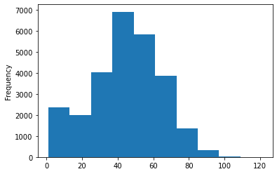

```python
data.num_lab_procedures.plot(kind='hist')
```

```
C:\Users\Ashvini Alashetty\Anaconda3\lib\site-packages\seaborn\distributions.py:2619: FutureWarning: `distplot` is a deprecated function and will be removed in a future version. Please adapt your code to use either `displot` (a figure-level function with similar flexibility) or `histplot` (an axes-l…
  warnings.warn(msg, FutureWarning)
```

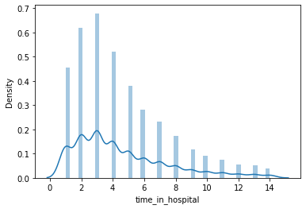

```python
import seaborn as sns
sns.distplot(data.time_in_hospital)
```

```
C:\Users\Ashvini Alashetty\Anaconda3\lib\site-packages\seaborn\_decorators.py:36: FutureWarning: Pass the following variables as keyword args: x, y. From version 0.12, the only valid positional argument will be `data`, and passing other arguments without an explicit keyword will result in an error o…
  warnings.warn(
```

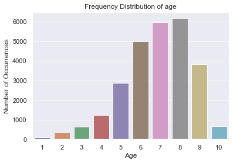

```python
import matplotlib.pyplot as plt
age_count = data['age'].value_counts()
sns.set(style="darkgrid")
sns.barplot(age_count.index, age_count.values, alpha=0.9)
plt.title('Frequency Distribution of age')
plt.ylabel('Number of Occurrences', fontsize=12)
plt.xlabel('Age', fontsize=12)
plt.show()
```

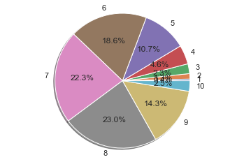

```python
labels = data['age'].astype('category').cat.categories.tolist()
counts = data['age'].value_counts()
sizes = [counts[var_cat] for var_cat in labels]
fig1, ax1 = plt.subplots()
ax1.pie(sizes, labels=labels, autopct='%1.1f%%', shadow=True) #autopct is show the % on plot
ax1.axis('equal')
plt.show()
```

# Feature Identification

```python
data.columns
```

```
Index(['encounter_id', 'patient_nbr', 'age', 'admission_type_id',
       'discharge_disposition_id', 'admission_source_id', 'time_in_hospital',
       'num_lab_procedures', 'num_procedures', 'num_medications',
       'number_outpatient', 'number_emergency', 'number_inpatient', 'diag_1',
       'diag_2', 'diag_3', 'number_diagnoses', 'treatments',
       'race_AfricanAmerican', 'race_Asian', 'race_Caucasian', 'race_Hispanic',
       'race_Other', 'gender_Female', 'gender_Male', 'max_glu_serum_>200',
       'max_glu_serum_>300', 'max_glu_serum_None', 'max_glu_serum_Norm',
       'A1Cresult_>7', 'A1Cresult_>8', 'A1Cresult_None', 'A1Cresult_Norm',
       'change_Ch', 'change_No', 'diabetesMed_Yes', 'readmitted_NO'],
      dtype='object')
```

### Considering the Domain knowledge, we would like to drop the Columns "diag_1" , "diag_2" ,"diag_3"

##### Since they contain the information about the codes of different types of treatments given to the patient. They don't contribute to the effectiveness of the treat (i.e, our problemm statement)

```python
data = data.drop(['diag_1','diag_2','diag_3'],axis = 1)
```

## With respect to the problem statement given, the output variable is observed to be the “treatments” feature

## The input variables are both Discrete Quantitative and Categorical and our output variable is Categorical

## Since we have a combination of Discrete Quantitative Variables and Categorical Variables, we cannot perform general Correlation tests

```python
#from IPython.display import Image
#Image("../input/correlation/Picture1.png")
```

### We will be performing Chi-Square Test of Independence for finding the Correlation btw the variables

# Chi-Square Test of Independence

```python
import pandas as pd
import numpy as np
import scipy.stats as stats
from scipy.stats import chi2_contingency

class ChiSquare:
    def __init__(self, dataframe):
        self.df = dataframe
        self.p = None #P-Value
        self.chi2 = None #Chi Test Statistic
        self.dof = None

        self.dfObserved = None
        self.dfExpected = None

    def _print_chisquare_result(self, colX, alpha):
        result = ""
        if self.p<alpha:
            result="{0} is IMPORTANT for Prediction".format(colX)
        else:
            result="{0} is NOT an important predictor. (Discard {0} from model)".format(colX)

        print(result)

    def TestIndependence(self,colX,colY, alpha=0.05):
        X = self.df[colX].astype(str)
        Y = self.df[colY].astype(str)

        self.dfObserved = pd.crosstab(Y,X)
        chi2, p, dof, expected = stats.chi2_contingency(self.dfObserved.values)
        self.p = p
        self.chi2 = chi2
        self.dof = dof

        self.dfExpected = pd.DataFrame(expected, columns=self.dfObserved.columns, index = self.dfObserved.index)

        self._print_chisquare_result(colX,alpha)
```

```python
data['dummyCat'] = np.random.choice([0, 1], size=(len(data),), p=[0.5, 0.5])

data.dummyCat.value_counts()
```

```
1    13444
0    13376
Name: dummyCat, dtype: int64
```

```python
#Initialize ChiSquare Class
cT = ChiSquare(data)

#Feature Selection
testColumns = ['encounter_id', 'patient_nbr', 'age', 'admission_type_id',
       'discharge_disposition_id', 'admission_source_id', 'time_in_hospital',
       'num_lab_procedures', 'num_procedures', 'num_medications',
       'number_outpatient', 'number_emergency', 'number_inpatient','number_diagnoses',
       'race_AfricanAmerican', 'race_Asian', 'race_Caucasian', 'race_Hispanic',
       'race_Other', 'gender_Female', 'gender_Male',
       'max_glu_serum_>200', 'max_glu_serum_>300', 'max_glu_serum_None',
       'max_glu_serum_Norm', 'A1Cresult_>7', 'A1Cresult_>8', 'A1Cresult_None',
       'A1Cresult_Norm', 'change_Ch', 'change_No', 'diabetesMed_Yes',
       'readmitted_NO', 'dummyCat']
for var in testColumns:
    cT.TestIndependence(colX=var,colY="treatments" )
```

```
encounter_id is NOT an important predictor. (Discard encounter_id from model)
patient_nbr is NOT an important predictor. (Discard patient_nbr from model)
age is IMPORTANT for Prediction
admission_type_id is IMPORTANT for Prediction
discharge_disposition_id is IMPORTANT for Prediction
admission_source_id is IMPORTANT for Prediction
time_in_hospital is IMPORTANT for Prediction
num_lab_procedures is NOT an important predictor. (Discard num_lab_procedures from model)
num_procedures is IMPORTANT for Prediction
num_medications is IMPORTANT for Prediction
number_outpatient is NOT an important predictor. (Discard number_outpatient from model)
number_emergency is NOT an important predictor. (Discard number_emergency from model)
number_inpatient is IMPORTANT for Prediction
number_diagnoses is IMPORTANT for Prediction
race_AfricanAmerican is IMPORTANT for Prediction
race_Asian is NOT an important predictor. (Discard race_Asian from model)
race_Caucasian is IMPORTANT for Prediction
race_Hispanic is IMPORTANT for Prediction
race_Other is NOT an important predictor. (Discard race_Other from model)
gender_Female is IMPORTANT for Prediction
gender_Male is IMPORTANT for Prediction
max_glu_serum_>200 is NOT an important predictor. (Discard max_glu_serum_>200 from model)
max_glu_serum_>300 is IMPORTANT for Prediction
max_glu_serum_None is IMPORTANT for Prediction
max_glu_serum_Norm is IMPORTANT for Prediction
A1Cresult_>7 is IMPORTANT for Prediction
A1Cresult_>8 is NOT an important predictor. (Discard A1Cresult_>8 from model)
A1Cresult_None is IMPORTANT for Prediction
A1Cresult_Norm is NOT an important predictor. (Discard A1Cresult_Norm from model)
change_Ch is IMPORTANT for Prediction
change_No is IMPORTANT for Prediction
diabetesMed_Yes is NOT an important predictor. (Discard diabetesMed_Yes from model)
readmitted_NO is NOT an important predictor. (Discard readmitted_NO from model)
dummyCat is IMPORTANT for Prediction
```

# Model Building

## Train Test Split

Since our target variable is Categorical , We would be importing the required Classification model packages

```python
from sklearn.model_selection import train_test_split
from sklearn.linear_model import LogisticRegression
from sklearn.neighbors import KNeighborsClassifier
from sklearn.naive_bayes import MultinomialNB,GaussianNB,BernoulliNB
from sklearn.tree import DecisionTreeClassifier
from sklearn.ensemble import RandomForestClassifier
from sklearn.metrics import accuracy_score,confusion_matrix,classification_report
```

```python
X = data.drop(['encounter_id','patient_nbr','num_lab_procedures','number_outpatient','number_emergency',
                      'race_Asian','race_Other','diabetesMed_Yes','max_glu_serum_>200','A1Cresult_>8','A1Cresult_Norm',
                      'readmitted_NO','dummyCat','treatments'],axis=1)
Y = data['treatments']
print(X.shape)
print(Y.shape)
```

```
(26820, 21)
(26820,)
```

```python
from sklearn.model_selection import train_test_split
X_train, X_test, y_train, y_test = train_test_split(X, Y, test_size=0.3, random_state=2)
X_train.shape,X_test.shape,y_train.shape,y_test.shape
```

```
((18774, 21), (8046, 21), (18774,), (8046,))
```

# Base Model

```python
y_p=[]
for i in range(y_test.shape[0]):
    y_p.append(y_test.mode()[0])#Highest class is assigned to a list which is compared with ytest
len(y_p)
```

```
8046
```

```python
y_pred=pd.Series(y_p)
```

```python
print("Accuracy : ",accuracy_score(y_test,y_pred))
```

```
Accuracy :  0.5437484464330102
```

## Our Baseline accuracy is 54%

#### We can set the accuracy as 54% and the models we build should be giving us accuracies greater than 54%

# Predictive Model Development - Iteration 1

## Baseline Models - Logistic Regression

```python
#Logistic Regression
m1=LogisticRegression()
m1.fit(X_train,y_train)
y_pred_lr=m1.predict(X_test)
Train_Score_lr = m1.score(X_train,y_train)
Test_Score_lr = accuracy_score(y_test,y_pred_lr)


print('Training Accuracy is:',Train_Score_lr)
print('Testing Accuracy is:',Test_Score_lr)
print(classification_report(y_test,y_pred_lr))
```

```
C:\Users\Ashvini Alashetty\Anaconda3\lib\site-packages\sklearn\linear_model\_logistic.py:444: ConvergenceWarning: lbfgs failed to converge (status=1):
STOP: TOTAL NO. of ITERATIONS REACHED LIMIT.

Increase the number of iterations (max_iter) or scale the data as shown in:
    https://scikit-learn.org/stable/modules/preprocessing.html
Please also refer to the documentation for alternative solver options:
    https://scikit-learn.org/stable/modules/linear_model.html#logistic-regression
  n_iter_i = _check_optimize_result(
```

```
Training Accuracy is: 0.7742622776179823
Testing Accuracy is: 0.767710663683818
              precision    recall  f1-score   support

     insulin       0.94      0.61      0.74      4375
          io       0.67      0.96      0.79      3671

    accuracy                           0.77      8046
   macro avg       0.81      0.78      0.77      8046
weighted avg       0.82      0.77      0.76      8046
```

## KNN

```python
m2 = KNeighborsClassifier()
m2.fit(X_train,y_train)
y_pred_knn = m2.predict(X_test)
Train_Score_knn = m2.score(X_train,y_train)
Test_Score_knn = accuracy_score(y_test,y_pred_knn)

print('Training Accuracy is :',Train_Score_knn)
print('Testing Accuracy is:',Test_Score_knn)
print(classification_report(y_test,y_pred_knn))
```

```
Training Accuracy is : 0.7978587408117609
Testing Accuracy is: 0.6731295053442704
              precision    recall  f1-score   support

     insulin       0.72      0.65      0.68      4375
          io       0.63      0.70      0.66      3671

    accuracy                           0.67      8046
   macro avg       0.67      0.68      0.67      8046
weighted avg       0.68      0.67      0.67      8046
```

## Decision Trees

```python
m4 = DecisionTreeClassifier()
m4.fit(X_train,y_train)
y_pred_dt=m4.predict(X_test)
Train_Score_dt = m4.score(X_train,y_train)
Test_Score_dt = accuracy_score(y_test,y_pred_dt)

print('Training Accuracy :',Train_Score_dt)
print('Testing Accuracy :',Test_Score_dt)
print(classification_report(y_test,y_pred_dt))
```

```
Training Accuracy : 0.9965910301480772
Testing Accuracy : 0.6982351478995774
              precision    recall  f1-score   support

     insulin       0.71      0.74      0.73      4375
          io       0.68      0.65      0.66      3671

    accuracy                           0.70      8046
   macro avg       0.70      0.69      0.69      8046
weighted avg       0.70      0.70      0.70      8046
```

## Random Forest

```python
m5 = RandomForestClassifier()
m5.fit(X_train,y_train)
y_pred_rf=m5.predict(X_test)
Train_Score_rf = m5.score(X_train,y_train)
Test_Score_rf = accuracy_score(y_test,y_pred_rf)

print('Training Accuracy :',Train_Score_rf)
print('Testing Accuracy :',Test_Score_rf)
print(classification_report(y_test,y_pred_rf))
```

```
Training Accuracy : 0.9965910301480772
Testing Accuracy : 0.7544121302510565
              precision    recall  f1-score   support

     insulin       0.84      0.67      0.75      4375
          io       0.69      0.85      0.76      3671

    accuracy                           0.75      8046
   macro avg       0.77      0.76      0.75      8046
weighted avg       0.77      0.75      0.75      8046
```

## SVM

```python
from sklearn.svm import SVC
from sklearn.preprocessing import StandardScaler
from sklearn.datasets import make_classification
from sklearn.model_selection import train_test_split
from sklearn.pipeline import Pipeline
#X_train, X_test, y_train, y_test = train_test_split(X, y,random_state=0)
pipe = Pipeline([('scaler', StandardScaler()), ('svc', SVC())])
from sklearn.model_selection import train_test_split
X_train, X_test, y_train, y_test = train_test_split(X, Y, test_size=0.3, random_state=2)
X_train.shape,X_test.shape,y_train.shape,y_test.shape
```

```
((18774, 21), (8046, 21), (18774,), (8046,))
```

```python
from sklearn.svm import SVC
poly_kernel_svm_clf = Pipeline([
    ("scaler", StandardScaler()),
    ("svm_clf", SVC(kernel="poly", degree=3, coef0=1, C=5))
])
poly_kernel_svm_clf.fit(X,Y)
```

```
Pipeline(steps=[('scaler', StandardScaler()),
                ('svm_clf', SVC(C=5, coef0=1, kernel='poly'))])
```

```python
poly_kernel_svm_clf.score(X_test, y_test)
```

```
0.7866020382798906
```

# Predictive Model Development - Iteration 2

## Hyperparameter Tuning

### For Decision Tree

```python
# GridSearchCV to find optimal max_depth
from sklearn.model_selection import KFold
from sklearn.model_selection import GridSearchCV


# specify number of folds for k-fold CV
n_folds = 3

# parameters to build the model on
parameters = {'max_depth': range(5, 15, 5),
    'min_samples_leaf': range(50, 150, 50),
    'min_samples_split': range(50, 150, 50),
    'criterion': ["entropy", "gini"]}

# instantiate the model
dtree = DecisionTreeClassifier(random_state = 100)

# fit tree on training data
tree = GridSearchCV(dtree, parameters,
                    cv=n_folds,
                   scoring="accuracy")
tree.fit(X_train, y_train)
```

```
GridSearchCV(cv=3, estimator=DecisionTreeClassifier(random_state=100),
             param_grid={'criterion': ['entropy', 'gini'],
                         'max_depth': range(5, 15, 5),
                         'min_samples_leaf': range(50, 150, 50),
                         'min_samples_split': range(50, 150, 50)},
             scoring='accuracy')
```

```python
tree.best_params_
```

```
{'criterion': 'gini',
 'max_depth': 5,
 'min_samples_leaf': 50,
 'min_samples_split': 50}
```

```python
m6 = DecisionTreeClassifier(criterion='gini',max_depth=5,min_samples_leaf=50,min_samples_split=50)
m6.fit(X_train,y_train)
y_pred_tdt=m6.predict(X_test)
Train_Score_tdt = m6.score(X_train,y_train)
Test_Score_tdt = accuracy_score(y_test,y_pred_tdt)

print('Training Accuracy :',Train_Score_tdt)
print('Testing Accuracy  :',Test_Score_tdt)
print(classification_report(y_test,y_pred_tdt))
```

```
Training Accuracy : 0.7775647171620326
Testing Accuracy  : 0.7672135222470793
              precision    recall  f1-score   support

     insulin       0.95      0.60      0.74      4375
          io       0.67      0.97      0.79      3671

    accuracy                           0.77      8046
   macro avg       0.81      0.78      0.76      8046
weighted avg       0.82      0.77      0.76      8046
```

### For KNN

```python
#Gridsearch CV to find Optimal K value for KNN model
grid = {'n_neighbors':np.arange(1,50)}
knn=KNeighborsClassifier()
knn_cv=GridSearchCV(knn,grid,cv=3)
knn_cv.fit(X_train,y_train)


print("Tuned Hyperparameter k: {}".format(knn_cv.best_params_))
```

```
Tuned Hyperparameter k: {'n_neighbors': 35}
```

```python
m7 = KNeighborsClassifier(n_neighbors=19)
m7.fit(X_train,y_train)
y_pred_tknn=m7.predict(X_test)
Train_Score_tknn = m7.score(X_train,y_train)
Test_Score_tknn = accuracy_score(y_test,y_pred_tknn)


print('Training Accuracy :',Train_Score_tknn)
print('Testing Accuracy  :',Test_Score_tknn)
print(classification_report(y_test,y_pred_tknn))
```

```
Training Accuracy : 0.7453392990305742
Testing Accuracy  : 0.6971165796669152
              precision    recall  f1-score   support

     insulin       0.75      0.66      0.70      4375
          io       0.65      0.75      0.69      3671

    accuracy                           0.70      8046
   macro avg       0.70      0.70      0.70      8046
weighted avg       0.70      0.70      0.70      8046
```

### For Random Forest

```python
parameter={'n_estimators':np.arange(1,101)}
gs = GridSearchCV(m5,parameter,cv=3)
gs.fit(X_train,y_train)
gs.best_params_
```

```
{'n_estimators': 87}
```

```python
m8 = RandomForestClassifier(n_estimators=73)
m8.fit(X_train,y_train)
y_pred_trf=m8.predict(X_test)
Train_Score_trf = m8.score(X_train,y_train)
Test_Score_trf = accuracy_score(y_test,y_pred_trf)


print('Training Accuracy :',Train_Score_trf)
print('Testing Accuracy  :',Test_Score_trf)
print(classification_report(y_test,y_pred_trf))
```

```
Training Accuracy : 0.9964844998402045
Testing Accuracy  : 0.756152125279642
              precision    recall  f1-score   support

     insulin       0.85      0.67      0.75      4375
          io       0.69      0.86      0.76      3671

    accuracy                           0.76      8046
   macro avg       0.77      0.76      0.76      8046
weighted avg       0.78      0.76      0.76      8046
```

```python
Model_Scores=pd.DataFrame({'Models':['Logistic Regression','KNN','Decision Tree','Random Forest','Tuned Decison Tree','Tuned KNN','Tuned Random Forest'],
             'Training Accuracy':[Train_Score_lr,Train_Score_knn,Train_Score_dt,Train_Score_rf,Train_Score_tdt,Train_Score_tknn,Train_Score_trf],
             'Testing Accuracy':[Test_Score_lr,Test_Score_knn,Test_Score_dt,Test_Score_rf,Test_Score_tdt,Test_Score_tknn,Test_Score_trf],
                })

Model_Scores.sort_values(by=('Testing Accuracy'),ascending=False)
```

|  | Models | Training Accuracy | Testing Accuracy |
| --- | --- | --- | --- |
| 0 | Logistic Regression | 0.774262 | 0.767711 |
| 4 | Tuned Decison Tree | 0.777565 | 0.767214 |
| 6 | Tuned Random Forest | 0.996484 | 0.756152 |
| 3 | Random Forest | 0.996591 | 0.754412 |
| 2 | Decision Tree | 0.996591 | 0.698235 |
| 5 | Tuned KNN | 0.745339 | 0.697117 |
| 1 | KNN | 0.797859 | 0.673130 |

```python
## from sklearn.model_selection import train_test_split
X_train, X_test, y_train, y_test = train_test_split(X, Y, test_size=0.3, random_state=2)
X_train.shape,X_test.shape,y_train.shape,y_test.shape
```

```
((18774, 21), (8046, 21), (18774,), (8046,))
```

```python
X_train.shape
```

```
(18774, 21)
```

```python
X_test.shape
```

```
(8046, 21)
```

```python
X = data.drop(['encounter_id','patient_nbr','num_lab_procedures','number_outpatient','number_emergency',
                      'race_Asian','race_Other','diabetesMed_Yes','max_glu_serum_>200','A1Cresult_>8','A1Cresult_Norm',
                      'readmitted_NO','dummyCat','treatments'],axis=1)
Y = data['treatments']
from sklearn.preprocessing import StandardScaler
sc = StandardScaler()
X= sc.fit_transform(X)
```

```python
from sklearn import preprocessing
from sklearn.neighbors import KNeighborsClassifier
from sklearn.model_selection import train_test_split
from sklearn.svm import SVC
from sklearn import model_selection
from sklearn.metrics import classification_report
from sklearn.metrics import accuracy_score
from pandas.plotting import scatter_matrix
from sklearn.metrics import f1_score
from sklearn.linear_model import LogisticRegression
from sklearn import tree
from sklearn.ensemble import RandomForestClassifier
from sklearn.metrics import classification_report
from sklearn.pipeline import make_pipeline
from sklearn.model_selection import cross_val_score
from sklearn.naive_bayes import GaussianNB
from sklearn.ensemble import GradientBoostingClassifier
```

```
           Name     Score
0           KNN  0.740380
1           SVM  0.770955
2           GNB  0.760030
3            LR  0.770992
4  decisiontree  0.700373
5  randomforest  0.728262
6            GB  0.774907
```

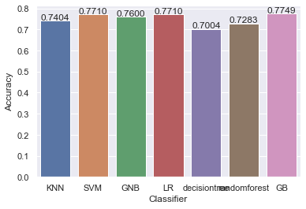

```python
models = []
models.append(('KNN', KNeighborsClassifier(n_neighbors = 5)))
models.append(('SVM', SVC(gamma='auto')))
models.append(('GNB', GaussianNB()))
models.append(('LR', LogisticRegression(solver='liblinear',random_state=0)))
models.append(('decisiontree', tree.DecisionTreeClassifier()))
models.append(('randomforest', RandomForestClassifier(max_depth=2, random_state=10, n_estimators=10)))
models.append(('GB', GradientBoostingClassifier()))

scores = []
names = []

for name, model in models:

    score = cross_val_score(model, X, Y, scoring='accuracy', cv=5).mean()

    names.append(name)
    scores.append(score)
kf_cross_val = pd.DataFrame({'Name': names, 'Score': scores})
print(kf_cross_val)

axis = sns.barplot(x = 'Name', y = 'Score', data = kf_cross_val)
axis.set(xlabel='Classifier', ylabel='Accuracy')
for p in axis.patches:
    height = p.get_height()
    axis.text(p.get_x() + p.get_width()/2, height + 0.005, '{:1.4f}'.format(height), ha="center")

plt.show()
```

```python
from sklearn.model_selection import GridSearchCV, KFold
from keras.models import Sequential
from keras.layers import Dense
from keras.wrappers.scikit_learn import KerasClassifier
from keras.optimizers import Adam
```

```python
def create_model():
    # create model
    model = Sequential()
    model.add(Dense(8, input_dim = 21, kernel_initializer='normal', activation='relu'))
    model.add(Dense(4, input_dim = 21, kernel_initializer='normal', activation='relu'))
    model.add(Dense(1, activation='sigmoid'))

    # compile the model
    adam = Adam(lr = 0.01)
    model.compile(loss = 'binary_crossentropy', optimizer = adam, metrics = ['accuracy'])
    return model

model = create_model()
print(model.summary())
```

```
Model: "sequential"
_________________________________________________________________
 Layer (type)                Output Shape              Param #
=================================================================
 dense (Dense)               (None, 8)                 176

 dense_1 (Dense)             (None, 4)                 36

 dense_2 (Dense)             (None, 1)                 5

=================================================================
Total params: 217
Trainable params: 217
Non-trainable params: 0
_________________________________________________________________
None
```

```
C:\Users\Ashvini Alashetty\Anaconda3\lib\site-packages\keras\optimizers\optimizer_v2\adam.py:110: UserWarning: The `lr` argument is deprecated, use `learning_rate` instead.
  super(Adam, self).__init__(name, **kwargs)
```

```python
model = KerasClassifier(build_fn = create_model, verbose = 1)
model.fit(X,Y)
```

```
C:\Users\Ashvini Alashetty\AppData\Local\Temp\ipykernel_10804\571249385.py:1: DeprecationWarning: KerasClassifier is deprecated, use Sci-Keras (https://github.com/adriangb/scikeras) instead. See https://www.adriangb.com/scikeras/stable/migration.html for help migrating.
  model = KerasClassifier(build_fn = create_model, verbose = 1)
```

```
<keras.callbacks.History at 0x2a3629487f0>
```

```python
from sklearn.model_selection import GridSearchCV
from sklearn.model_selection import KFold
from keras.models import Sequential
from keras.layers import Dense
from keras.wrappers.scikit_learn import KerasClassifier
from keras.optimizers import Adam

# Define a random seed
seed = 6
np.random.seed(seed)

# Start defining the model
def create_model():
    # create model
    model = Sequential()
    model.add(Dense(8, input_dim = 21, kernel_initializer='normal', activation='relu'))
    model.add(Dense(4, input_dim = 21, kernel_initializer='normal', activation='relu'))
    model.add(Dense(1, activation='sigmoid'))

    # compile the model
    adam = Adam(lr = 0.01)
    model.compile(loss = 'binary_crossentropy', optimizer = adam, metrics = ['accuracy'])
    return model

# create the model
model = KerasClassifier(build_fn = create_model, verbose = 1)

# define the grid search parameters
batch_size = [10,15, 20]
epochs = [10, 50, 100]

# make a dictionary of the grid search parameters
param_grid = dict(batch_size=batch_size, epochs=epochs)

# build and fit the GridSearchCV
grid = GridSearchCV(estimator = model, param_grid = param_grid, cv = KFold(random_state=None), verbose = 10)
grid_results = grid.fit(X, Y)

# summarize the results
print("Best: {0}, using {1}".format(grid_results.best_score_, grid_results.best_params_))
means = grid_results.cv_results_['mean_test_score']
stds = grid_results.cv_results_['std_test_score']
params = grid_results.cv_results_['params']
for mean, stdev, param in zip(means, stds, params):
    print('{0} ({1}) with: {2}'.format(mean, stdev, param))
```

```
Fitting 5 folds for each of 9 candidates, totalling 45 fits
[CV 1/5; 1/9] START batch_size=10, epochs=10....................................
```

```
C:\Users\Ashvini Alashetty\AppData\Local\Temp\ipykernel_10804\2936010327.py:26: DeprecationWarning: KerasClassifier is deprecated, use Sci-Keras (https://github.com/adriangb/scikeras) instead. See https://www.adriangb.com/scikeras/stable/migration.html for help migrating.
  model = KerasClassifier(build_fn = create_model, verbose = 1)
```

```
[CV 1/5; 1/9] END .....batch_size=10, epochs=10;, score=0.822 total time=  40.7s
[CV 2/5; 1/9] START batch_size=10, epochs=10....................................
[CV 2/5; 1/9] END .....batch_size=10, epochs=10;, score=0.825 total time=  36.2s
[CV 3/5; 1/9] START batch_size=10, epochs=10....................................
[CV 3/5; 1/9] END .....batch_size=10, epochs=10;, score=0.749 total time=  39.1s
[CV 4/5; 1/9] START batch_size=10, epochs=10....................................
[CV 4/5; 1/9] END .....batch_size=10, epochs=10;, score=0.735 total time=  36.6s
[CV 5/5; 1/9] START batch_size=10, epochs=10....................................
[CV 5/5; 1/9] END .....batch_size=10, epochs=10;, score=0.746 total time=  36.8s
[CV 1/5; 2/9] START batch_size=10, epochs=50....................................
[CV 1/5; 2/9] END .....batch_size=10, epochs=50;, score=0.815 total time= 2.9min
[CV 2/5; 2/9] START batch_size=10, epochs=50....................................
[CV 2/5; 2/9] END .....batch_size=10, epochs=50;, score=0.827 total time= 3.0min
[CV 3/5; 2/9] START batch_size=10, epochs=50....................................
[CV 3/5; 2/9] END .....batch_size=10, epochs=50;, score=0.750 total time= 2.9min
[CV 4/5; 2/9] START batch_size=10, epochs=50....................................
[CV 4/5; 2/9] END .....batch_size=10, epochs=50;, score=0.731 total time= 2.9min
[CV 5/5; 2/9] START batch_size=10, epochs=50....................................
[CV 5/5; 2/9] END .....batch_size=10, epochs=50;, score=0.745 total time= 2.9min
[CV 1/5; 3/9] START batch_size=10, epochs=100...................................
[CV 1/5; 3/9] END ....batch_size=10, epochs=100;, score=0.817 total time=36.3min
[CV 2/5; 3/9] START batch_size=10, epochs=100...................................
[CV 2/5; 3/9] END ....batch_size=10, epochs=100;, score=0.831 total time= 8.9min
[CV 3/5; 3/9] START batch_size=10, epochs=100...................................
[CV 3/5; 3/9] END ....batch_size=10, epochs=100;, score=0.750 total time= 8.5min
[CV 4/5; 3/9] START batch_size=10, epochs=100...................................
[CV 4/5; 3/9] END ....batch_size=10, epochs=100;, score=0.737 total time= 8.4min
[CV 5/5; 3/9] START batch_size=10, epochs=100...................................
[CV 5/5; 3/9] END ....batch_size=10, epochs=100;, score=0.746 total time=42.1min
[CV 1/5; 4/9] START batch_size=15, epochs=10....................................
[CV 1/5; 4/9] END .....batch_size=15, epochs=10;, score=0.816 total time=  39.6s
[CV 2/5; 4/9] START batch_size=15, epochs=10....................................
[CV 2/5; 4/9] END .....batch_size=15, epochs=10;, score=0.831 total time=  40.3s
[CV 3/5; 4/9] START batch_size=15, epochs=10....................................
[CV 3/5; 4/9] END .....batch_size=15, epochs=10;, score=0.751 total time=  38.9s
[CV 4/5; 4/9] START batch_size=15, epochs=10....................................
[CV 4/5; 4/9] END .....batch_size=15, epochs=10;, score=0.738 total time=  38.6s
[CV 5/5; 4/9] START batch_size=15, epochs=10....................................
[CV 5/5; 4/9] END .....batch_size=15, epochs=10;, score=0.744 total time=  38.5s
[CV 1/5; 5/9] START batch_size=15, epochs=50....................................
```

[output cut: 44 more lines]

```
[CV 3/5; 9/9] END ...batch_size=20, epochs=100;, score=0.745 total time=174.8min
[CV 4/5; 9/9] START batch_size=20, epochs=100...................................
[CV 4/5; 9/9] END ....batch_size=20, epochs=100;, score=0.729 total time= 4.8min
[CV 5/5; 9/9] START batch_size=20, epochs=100...................................
[CV 5/5; 9/9] END ....batch_size=20, epochs=100;, score=0.742 total time= 4.8min
Best: 0.7759880542755127, using {'batch_size': 15, 'epochs': 10}
0.7756152033805848 (0.039424230673592006) with: {'batch_size': 10, 'epochs': 10}
0.7736763596534729 (0.039632527432348186) with: {'batch_size': 10, 'epochs': 50}
0.7757643461227417 (0.03948937911501822) with: {'batch_size': 10, 'epochs': 100}
0.7759880542755127 (0.03941930447288492) with: {'batch_size': 15, 'epochs': 10}
0.7711782217025757 (0.042607940468819494) with: {'batch_size': 15, 'epochs': 50}
0.7725577831268311 (0.03922368449722001) with: {'batch_size': 15, 'epochs': 100}
0.7746457815170288 (0.03826825616070188) with: {'batch_size': 20, 'epochs': 10}
0.7758762121200562 (0.038363864230447624) with: {'batch_size': 20, 'epochs': 50}
0.7711409330368042 (0.040649125617765416) with: {'batch_size': 20, 'epochs': 100}
```

```python
from keras.layers import Dropout

# Define a random seed
seed = 6
np.random.seed(seed)

# Start defining the model
def create_model(learn_rate, dropout_rate):
    # create model
    model = Sequential()
    model.add(Dense(8, input_dim = 21, kernel_initializer='normal', activation='relu'))
    model.add(Dropout(dropout_rate))
    model.add(Dense(4, input_dim = 21, kernel_initializer='normal', activation='relu'))
    model.add(Dropout(dropout_rate))
    model.add(Dense(1, activation='sigmoid'))

    # compile the model
    adam = Adam(lr = learn_rate)
    model.compile(loss = 'binary_crossentropy', optimizer = adam, metrics = ['accuracy'])
    return model

# create the model
model = KerasClassifier(build_fn = create_model, epochs = 10, batch_size = 10, verbose = 0)

# define the grid search parameters
learn_rate = [0.001, 0.01, 0.1]
dropout_rate = [0.0, 0.1, 0.2]

# make a dictionary of the grid search parameters
param_grid = dict(learn_rate=learn_rate, dropout_rate=dropout_rate)

# build and fit the GridSearchCV
grid = GridSearchCV(estimator = model, param_grid = param_grid, cv = KFold(random_state=None), verbose = 10)
grid_results = grid.fit(X, Y)

# summarize the results
print("Best: {0}, using {1}".format(grid_results.best_score_, grid_results.best_params_))
means = grid_results.cv_results_['mean_test_score']
stds = grid_results.cv_results_['std_test_score']
params = grid_results.cv_results_['params']
for mean, stdev, param in zip(means, stds, params):
    print('{0} ({1}) with: {2}'.format(mean, stdev, param))
```

```
Fitting 5 folds for each of 9 candidates, totalling 45 fits
[CV 1/5; 1/9] START dropout_rate=0.0, learn_rate=0.001..........................
```

```
C:\Users\Ashvini Alashetty\AppData\Local\Temp\ipykernel_10804\3940067526.py:23: DeprecationWarning: KerasClassifier is deprecated, use Sci-Keras (https://github.com/adriangb/scikeras) instead. See https://www.adriangb.com/scikeras/stable/migration.html for help migrating.
  model = KerasClassifier(build_fn = create_model, epochs = 10, batch_size = 10, verbose = 0)
```

```
[CV 1/5; 1/9] END dropout_rate=0.0, learn_rate=0.001;, score=0.819 total time=  46.3s
[CV 2/5; 1/9] START dropout_rate=0.0, learn_rate=0.001..........................
[CV 2/5; 1/9] END dropout_rate=0.0, learn_rate=0.001;, score=0.830 total time=  46.2s
[CV 3/5; 1/9] START dropout_rate=0.0, learn_rate=0.001..........................
[CV 3/5; 1/9] END dropout_rate=0.0, learn_rate=0.001;, score=0.748 total time=  47.2s
[CV 4/5; 1/9] START dropout_rate=0.0, learn_rate=0.001..........................
[CV 4/5; 1/9] END dropout_rate=0.0, learn_rate=0.001;, score=0.737 total time=  46.5s
[CV 5/5; 1/9] START dropout_rate=0.0, learn_rate=0.001..........................
[CV 5/5; 1/9] END dropout_rate=0.0, learn_rate=0.001;, score=0.747 total time=  46.5s
[CV 1/5; 2/9] START dropout_rate=0.0, learn_rate=0.01...........................
[CV 1/5; 2/9] END dropout_rate=0.0, learn_rate=0.01;, score=0.814 total time=  46.5s
[CV 2/5; 2/9] START dropout_rate=0.0, learn_rate=0.01...........................
[CV 2/5; 2/9] END dropout_rate=0.0, learn_rate=0.01;, score=0.831 total time=  47.2s
[CV 3/5; 2/9] START dropout_rate=0.0, learn_rate=0.01...........................
[CV 3/5; 2/9] END dropout_rate=0.0, learn_rate=0.01;, score=0.748 total time=  47.2s
[CV 4/5; 2/9] START dropout_rate=0.0, learn_rate=0.01...........................
[CV 4/5; 2/9] END dropout_rate=0.0, learn_rate=0.01;, score=0.732 total time=  46.4s
[CV 5/5; 2/9] START dropout_rate=0.0, learn_rate=0.01...........................
[CV 5/5; 2/9] END dropout_rate=0.0, learn_rate=0.01;, score=0.744 total time=  47.1s
[CV 1/5; 3/9] START dropout_rate=0.0, learn_rate=0.1............................
[CV 1/5; 3/9] END dropout_rate=0.0, learn_rate=0.1;, score=0.598 total time=  46.5s
[CV 2/5; 3/9] START dropout_rate=0.0, learn_rate=0.1............................
[CV 2/5; 3/9] END dropout_rate=0.0, learn_rate=0.1;, score=0.796 total time=  46.6s
[CV 3/5; 3/9] START dropout_rate=0.0, learn_rate=0.1............................
[CV 3/5; 3/9] END dropout_rate=0.0, learn_rate=0.1;, score=0.730 total time=  45.9s
[CV 4/5; 3/9] START dropout_rate=0.0, learn_rate=0.1............................
[CV 4/5; 3/9] END dropout_rate=0.0, learn_rate=0.1;, score=0.723 total time=  45.5s
[CV 5/5; 3/9] START dropout_rate=0.0, learn_rate=0.1............................
[CV 5/5; 3/9] END dropout_rate=0.0, learn_rate=0.1;, score=0.724 total time=  46.5s
[CV 1/5; 4/9] START dropout_rate=0.1, learn_rate=0.001..........................
[CV 1/5; 4/9] END dropout_rate=0.1, learn_rate=0.001;, score=0.815 total time=  48.3s
[CV 2/5; 4/9] START dropout_rate=0.1, learn_rate=0.001..........................
[CV 2/5; 4/9] END dropout_rate=0.1, learn_rate=0.001;, score=0.830 total time=  48.2s
[CV 3/5; 4/9] START dropout_rate=0.1, learn_rate=0.001..........................
[CV 3/5; 4/9] END dropout_rate=0.1, learn_rate=0.001;, score=0.752 total time=  48.4s
[CV 4/5; 4/9] START dropout_rate=0.1, learn_rate=0.001..........................
[CV 4/5; 4/9] END dropout_rate=0.1, learn_rate=0.001;, score=0.736 total time=  48.6s
[CV 5/5; 4/9] START dropout_rate=0.1, learn_rate=0.001..........................
[CV 5/5; 4/9] END dropout_rate=0.1, learn_rate=0.001;, score=0.740 total time=  48.4s
[CV 1/5; 5/9] START dropout_rate=0.1, learn_rate=0.01...........................
```

[output cut: 44 more lines]

```
[CV 3/5; 9/9] END dropout_rate=0.2, learn_rate=0.1;, score=0.730 total time=  47.4s
[CV 4/5; 9/9] START dropout_rate=0.2, learn_rate=0.1............................
[CV 4/5; 9/9] END dropout_rate=0.2, learn_rate=0.1;, score=0.521 total time=  47.0s
[CV 5/5; 9/9] START dropout_rate=0.2, learn_rate=0.1............................
[CV 5/5; 9/9] END dropout_rate=0.2, learn_rate=0.1;, score=0.546 total time=  47.7s
Best: 0.7761744856834412, using {'dropout_rate': 0.0, 'learn_rate': 0.001}
0.7761744856834412 (0.03971391743259463) with: {'dropout_rate': 0.0, 'learn_rate': 0.001}
0.7736017942428589 (0.0402573386094615) with: {'dropout_rate': 0.0, 'learn_rate': 0.01}
0.714354956150055 (0.06420136787161651) with: {'dropout_rate': 0.0, 'learn_rate': 0.1}
0.7745339155197144 (0.03953023727750645) with: {'dropout_rate': 0.1, 'learn_rate': 0.001}
0.7750186443328857 (0.03956130587449775) with: {'dropout_rate': 0.1, 'learn_rate': 0.01}
0.7050708413124085 (0.08575810161678547) with: {'dropout_rate': 0.1, 'learn_rate': 0.1}
0.7755033493041992 (0.03874302983565182) with: {'dropout_rate': 0.2, 'learn_rate': 0.001}
0.7729679346084595 (0.040647184786782975) with: {'dropout_rate': 0.2, 'learn_rate': 0.01}
0.6109246790409089 (0.13210574392657645) with: {'dropout_rate': 0.2, 'learn_rate': 0.1}
```

```python
seed = 6
np.random.seed(seed)

# Start defining the model
def create_model(activation, init):
    # create model
    model = Sequential()
    model.add(Dense(4, input_dim = 21, kernel_initializer= init, activation= activation))
    model.add(Dense(4, input_dim = 21, kernel_initializer= init, activation= activation))
    model.add(Dense(1, activation='sigmoid'))

    # compile the model
    adam = Adam(lr = 0.001)
    model.compile(loss = 'hinge', optimizer = adam, metrics = ['accuracy'])
    return model

# create the model
model = KerasClassifier(build_fn = create_model, epochs = 100, batch_size = 10, verbose = 0)

# define the grid search parameters
activation = ['softmax', 'relu', 'tanh', 'linear']
init = ['uniform', 'normal', 'zero']

# make a dictionary of the grid search parameters
param_grid = dict(activation = activation, init = init)

# build and fit the GridSearchCV
grid = GridSearchCV(estimator = model, param_grid = param_grid, cv = KFold(random_state=None), verbose = 10)
grid_results = grid.fit(X, Y)

# summarize the results
print("Best: {0}, using {1}".format(grid_results.best_score_, grid_results.best_params_))
means = grid_results.cv_results_['mean_test_score']
stds = grid_results.cv_results_['std_test_score']
params = grid_results.cv_results_['params']
for mean, stdev, param in zip(means, stds, params):
    print('{0} ({1}) with: {2}'.format(mean, stdev, param))
```

```
Fitting 5 folds for each of 12 candidates, totalling 60 fits
[CV 1/5; 1/12] START activation=softmax, init=uniform...........................
```

[output not shown]

```
[CV 1/5; 1/12] END activation=softmax, init=uniform;, score=0.817 total time=  47.8s
[CV 2/5; 1/12] START activation=softmax, init=uniform...........................
[CV 2/5; 1/12] END activation=softmax, init=uniform;, score=0.831 total time=  47.1s
[CV 3/5; 1/12] START activation=softmax, init=uniform...........................
[CV 3/5; 1/12] END activation=softmax, init=uniform;, score=0.753 total time=  47.0s
[CV 4/5; 1/12] START activation=softmax, init=uniform...........................
[CV 4/5; 1/12] END activation=softmax, init=uniform;, score=0.738 total time=  47.0s
[CV 5/5; 1/12] START activation=softmax, init=uniform...........................
[CV 5/5; 1/12] END activation=softmax, init=uniform;, score=0.745 total time=  46.4s
[CV 1/5; 2/12] START activation=softmax, init=normal............................
[CV 1/5; 2/12] END activation=softmax, init=normal;, score=0.820 total time=  47.9s
[CV 2/5; 2/12] START activation=softmax, init=normal............................
[CV 2/5; 2/12] END activation=softmax, init=normal;, score=0.827 total time=  47.5s
[CV 3/5; 2/12] START activation=softmax, init=normal............................
[CV 3/5; 2/12] END activation=softmax, init=normal;, score=0.752 total time=  47.2s
[CV 4/5; 2/12] START activation=softmax, init=normal............................
[CV 4/5; 2/12] END activation=softmax, init=normal;, score=0.732 total time=  46.4s
[CV 5/5; 2/12] START activation=softmax, init=normal............................
[CV 5/5; 2/12] END activation=softmax, init=normal;, score=0.747 total time=  46.8s
[CV 1/5; 3/12] START activation=softmax, init=zero..............................
[CV 1/5; 3/12] END activation=softmax, init=zero;, score=0.598 total time=  47.4s
[CV 2/5; 3/12] START activation=softmax, init=zero..............................
[CV 2/5; 3/12] END activation=softmax, init=zero;, score=0.545 total time=  47.7s
[CV 3/5; 3/12] START activation=softmax, init=zero..............................
[CV 3/5; 3/12] END activation=softmax, init=zero;, score=0.526 total time=  47.6s
[CV 4/5; 3/12] START activation=softmax, init=zero..............................
[CV 4/5; 3/12] END activation=softmax, init=zero;, score=0.521 total time=  47.1s
[CV 5/5; 3/12] START activation=softmax, init=zero..............................
[CV 5/5; 3/12] END activation=softmax, init=zero;, score=0.546 total time=  46.8s
[CV 1/5; 4/12] START activation=relu, init=uniform..............................
[CV 1/5; 4/12] END activation=relu, init=uniform;, score=0.815 total time=  46.2s
[CV 2/5; 4/12] START activation=relu, init=uniform..............................
[CV 2/5; 4/12] END activation=relu, init=uniform;, score=0.826 total time=  45.2s
[CV 3/5; 4/12] START activation=relu, init=uniform..............................
[CV 3/5; 4/12] END activation=relu, init=uniform;, score=0.751 total time=  46.4s
[CV 4/5; 4/12] START activation=relu, init=uniform..............................
[CV 4/5; 4/12] END activation=relu, init=uniform;, score=0.736 total time=  46.5s
[CV 5/5; 4/12] START activation=relu, init=uniform..............................
[CV 5/5; 4/12] END activation=relu, init=uniform;, score=0.746 total time=  47.1s
[CV 1/5; 5/12] START activation=relu, init=normal...............................
```

[output cut: 77 more lines]

```
[CV 5/5; 12/12] START activation=linear, init=zero..............................
[CV 5/5; 12/12] END activation=linear, init=zero;, score=0.546 total time=  46.3s
Best: 0.7767710566520691, using {'activation': 'softmax', 'init': 'uniform'}
0.7767710566520691 (0.03928772081034712) with: {'activation': 'softmax', 'init': 'uniform'}
0.7758389353752136 (0.0396310496506905) with: {'activation': 'softmax', 'init': 'normal'}
0.5471662998199462 (0.02735986764594533) with: {'activation': 'softmax', 'init': 'zero'}
0.7747203588485718 (0.037803744650104415) with: {'activation': 'relu', 'init': 'uniform'}
0.7740119218826294 (0.03945504698352933) with: {'activation': 'relu', 'init': 'normal'}
0.5471662998199462 (0.02735986764594533) with: {'activation': 'relu', 'init': 'zero'}
0.7731170892715454 (0.03808611096977004) with: {'activation': 'tanh', 'init': 'uniform'}
0.7723713636398315 (0.036042468558100026) with: {'activation': 'tanh', 'init': 'normal'}
0.5471662998199462 (0.02735986764594533) with: {'activation': 'tanh', 'init': 'zero'}
0.7715137839317322 (0.04238548790407252) with: {'activation': 'linear', 'init': 'uniform'}
0.7697986483573913 (0.04368775477731467) with: {'activation': 'linear', 'init': 'normal'}
0.5471662998199462 (0.02735986764594533) with: {'activation': 'linear', 'init': 'zero'}
```

```python
seed = 6
np.random.seed(seed)
from keras.layers import Dropout
# Start defining the model
def create_model(neuron1, neuron2):
    # create model
    model = Sequential()
    model.add(Dense(neuron1, input_dim = 21, kernel_initializer= 'normal', activation= 'relu'))
    model.add(Dense(neuron2, input_dim = neuron1, kernel_initializer= 'normal', activation= 'linear'))
    model.add(Dense(1, activation='sigmoid'))

    # compile the model
    adam = Adam(lr = 0.001)
    model.compile(loss = 'hinge', optimizer = adam, metrics = ['accuracy'])
    return model

# create the model
model = KerasClassifier(build_fn = create_model, epochs = 10, batch_size = 10, verbose = 0)

# define the grid search parameters
neuron1 = [4, 8, 16]
neuron2 = [2, 4, 8]

# make a dictionary of the grid search parameters
param_grid = dict(neuron1 = neuron1, neuron2 = neuron2)

# build and fit the GridSearchCV
grid = GridSearchCV(estimator = model, param_grid = param_grid, cv = KFold(random_state=None), refit = True, verbose = 10)
grid_results = grid.fit(X, Y)

# summarize the results
print("Best: {0}, using {1}".format(grid_results.best_score_, grid_results.best_params_))
means = grid_results.cv_results_['mean_test_score']
stds = grid_results.cv_results_['std_test_score']
params = grid_results.cv_results_['params']
for mean, stdev, param in zip(means, stds, params):
    print('{0} ({1}) with: {2}'.format(mean, stdev, param))
```

```
Fitting 5 folds for each of 9 candidates, totalling 45 fits
[CV 1/5; 1/9] START neuron1=4, neuron2=2........................................
```

```
C:\Users\Ashvini Alashetty\AppData\Local\Temp\ipykernel_10804\2656936257.py:18: DeprecationWarning: KerasClassifier is deprecated, use Sci-Keras (https://github.com/adriangb/scikeras) instead. See https://www.adriangb.com/scikeras/stable/migration.html for help migrating.
  model = KerasClassifier(build_fn = create_model, epochs = 10, batch_size = 10, verbose = 0)
```

```
[CV 1/5; 1/9] END .........neuron1=4, neuron2=2;, score=0.819 total time=  49.0s
[CV 2/5; 1/9] START neuron1=4, neuron2=2........................................
[CV 2/5; 1/9] END .........neuron1=4, neuron2=2;, score=0.830 total time=  45.5s
[CV 3/5; 1/9] START neuron1=4, neuron2=2........................................
[CV 3/5; 1/9] END .........neuron1=4, neuron2=2;, score=0.754 total time=11.8min
[CV 4/5; 1/9] START neuron1=4, neuron2=2........................................
[CV 4/5; 1/9] END .........neuron1=4, neuron2=2;, score=0.735 total time=  47.5s
[CV 5/5; 1/9] START neuron1=4, neuron2=2........................................
[CV 5/5; 1/9] END .........neuron1=4, neuron2=2;, score=0.744 total time=  47.1s
[CV 1/5; 2/9] START neuron1=4, neuron2=4........................................
[CV 1/5; 2/9] END .........neuron1=4, neuron2=4;, score=0.817 total time=  47.2s
[CV 2/5; 2/9] START neuron1=4, neuron2=4........................................
[CV 2/5; 2/9] END .........neuron1=4, neuron2=4;, score=0.832 total time=  48.3s
[CV 3/5; 2/9] START neuron1=4, neuron2=4........................................
[CV 3/5; 2/9] END .........neuron1=4, neuron2=4;, score=0.750 total time=  47.8s
[CV 4/5; 2/9] START neuron1=4, neuron2=4........................................
[CV 4/5; 2/9] END .........neuron1=4, neuron2=4;, score=0.739 total time=  45.9s
[CV 5/5; 2/9] START neuron1=4, neuron2=4........................................
[CV 5/5; 2/9] END .........neuron1=4, neuron2=4;, score=0.745 total time=  47.3s
[CV 1/5; 3/9] START neuron1=4, neuron2=8........................................
[CV 1/5; 3/9] END .........neuron1=4, neuron2=8;, score=0.821 total time=  48.2s
[CV 2/5; 3/9] START neuron1=4, neuron2=8........................................
[CV 2/5; 3/9] END .........neuron1=4, neuron2=8;, score=0.827 total time=  49.3s
[CV 3/5; 3/9] START neuron1=4, neuron2=8........................................
[CV 3/5; 3/9] END .........neuron1=4, neuron2=8;, score=0.753 total time=  47.3s
[CV 4/5; 3/9] START neuron1=4, neuron2=8........................................
[CV 4/5; 3/9] END .........neuron1=4, neuron2=8;, score=0.738 total time=  47.2s
[CV 5/5; 3/9] START neuron1=4, neuron2=8........................................
[CV 5/5; 3/9] END .........neuron1=4, neuron2=8;, score=0.744 total time=  48.5s
[CV 1/5; 4/9] START neuron1=8, neuron2=2........................................
[CV 1/5; 4/9] END .........neuron1=8, neuron2=2;, score=0.817 total time=  47.4s
[CV 2/5; 4/9] START neuron1=8, neuron2=2........................................
[CV 2/5; 4/9] END .........neuron1=8, neuron2=2;, score=0.825 total time=  48.6s
[CV 3/5; 4/9] START neuron1=8, neuron2=2........................................
[CV 3/5; 4/9] END .........neuron1=8, neuron2=2;, score=0.752 total time=  50.0s
[CV 4/5; 4/9] START neuron1=8, neuron2=2........................................
[CV 4/5; 4/9] END .........neuron1=8, neuron2=2;, score=0.737 total time=  45.8s
[CV 5/5; 4/9] START neuron1=8, neuron2=2........................................
[CV 5/5; 4/9] END .........neuron1=8, neuron2=2;, score=0.745 total time=  47.8s
[CV 1/5; 5/9] START neuron1=8, neuron2=4........................................
```

[output cut: 44 more lines]

```
[CV 3/5; 9/9] END ........neuron1=16, neuron2=8;, score=0.752 total time=  47.9s
[CV 4/5; 9/9] START neuron1=16, neuron2=8.......................................
[CV 4/5; 9/9] END ........neuron1=16, neuron2=8;, score=0.736 total time=  47.4s
[CV 5/5; 9/9] START neuron1=16, neuron2=8.......................................
[CV 5/5; 9/9] END ........neuron1=16, neuron2=8;, score=0.748 total time=  49.2s
Best: 0.777218496799469, using {'neuron1': 16, 'neuron2': 4}
0.7765846371650695 (0.03999176536658578) with: {'neuron1': 4, 'neuron2': 2}
0.7765473484992981 (0.03960314735768787) with: {'neuron1': 4, 'neuron2': 4}
0.7763236403465271 (0.03905520597364454) with: {'neuron1': 4, 'neuron2': 8}
0.7752050757408142 (0.03766499305065959) with: {'neuron1': 8, 'neuron2': 2}
0.7767337799072266 (0.03911482170145419) with: {'neuron1': 8, 'neuron2': 4}
0.7762117743492126 (0.03892349338936219) with: {'neuron1': 8, 'neuron2': 8}
0.7758762001991272 (0.03880111749143033) with: {'neuron1': 16, 'neuron2': 2}
0.777218496799469 (0.037871050576525955) with: {'neuron1': 16, 'neuron2': 4}
0.7760253548622131 (0.038316393899284096) with: {'neuron1': 16, 'neuron2': 8}
```

```python
y_pred = grid.predict(X)
from sklearn.metrics import classification_report, accuracy_score

print(accuracy_score(Y, y_pred))
print(classification_report(Y, y_pred))
```

```
0.780462341536167
              precision    recall  f1-score   support

     insulin       0.94      0.64      0.76     14675
          io       0.69      0.95      0.80     12145

    accuracy                           0.78     26820
   macro avg       0.81      0.80      0.78     26820
weighted avg       0.83      0.78      0.78     26820
```

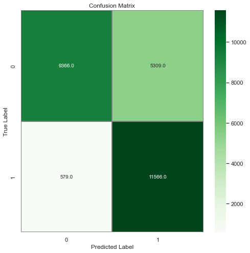

```python
# confusion matrix
import seaborn as sns
from sklearn.metrics import confusion_matrix
# compute the confusion matrix
confusion_mtx = confusion_matrix(Y, y_pred)
# plot the confusion matrix
f,ax = plt.subplots(figsize=(8, 8))
sns.heatmap(confusion_mtx, annot=True, linewidths=0.01,cmap="Greens",linecolor="gray", fmt= '.1f',ax=ax)
plt.xlabel("Predicted Label")
plt.ylabel("True Label")
plt.title("Confusion Matrix")
plt.show()
```

```python
from sklearn.metrics import classification_report

# Generate a classification report
report = classification_report(Y, y_pred, target_names=['0','1'])

print(report)
```

```
              precision    recall  f1-score   support

           0       0.94      0.64      0.76     14675
           1       0.69      0.95      0.80     12145

    accuracy                           0.78     26820
   macro avg       0.81      0.80      0.78     26820
weighted avg       0.83      0.78      0.78     26820
```